# ford_go_bike_explanatory slides

## Investigation Overview

In this investigation, I wanted to look at distance, duration and age in relation to each other and in terms of local and regional time scale. The main focus was on day periods, weekdays and month days.

## Dataset Overview

The dataset consisted of 183412 trips mainly over February with provided with other attributes like duration, stations, coordinates and some of the riders' information. Other attributes have been deduced to better investigate the data from numerous aspects like distance, age, week days, month days and day sequence. Hundreds of data points were removed from the analysis due to inconsistencies or missing information.

```python
# import all packages and set plots to be embedded inline
import numpy as np
import pandas as pd
import matplotlib.pyplot as plt
import seaborn as sb

%matplotlib inline
```

```python
ford= pd.read_csv('fordgobike.csv')
ford.head(1)
```

|  | duration_sec | start_time | end_time | start_station_id | start_station_name | start_station_latitude | start_station_longitude | end_station_id | end_station_name | end_station_latitude | end_station_longitude | bike_id | user_type | member_birth_year | member_gender | bike_share_for_all_trip |
| --- | --- | --- | --- | --- | --- | --- | --- | --- | --- | --- | --- | --- | --- | --- | --- | --- |
| 0 | 52185 | 2019-02-28 17:32:10.1450 | 2019-03-01 08:01:55.9750 | 21.0 | Montgomery St BART Station (Market St at 2nd St) | 37.789625 | -122.400811 | 13.0 | Commercial St at Montgomery St | 37.794231 | -122.402923 | 4902 | Customer | 1984.0 | Male | No |

```python
#Transforming start and end time columns to datetime type
ford['start_time'] = pd.to_datetime(ford['start_time'])
ford['end_time'] = pd.to_datetime(ford['end_time'])
```

```python
#Extracting days of week and days of month from the datetime columns
ford['dayofmonth'] = ford['start_time'].dt.day
ford['dayofweek'] = ford['start_time'].dt.weekday
ford['dayofweek'].replace({0, 1, 2, 3, 4, 5, 6},{'Monday', 'Tuesday', 'Wednesday', 'Thursday', 'Friday', 'Saturday', 'Sunday'}, inplace=True)
print(ford['dayofmonth'].unique())
print(ford['dayofweek'].unique())
```

```
[28 27 26 25 24 23 22 21 20 19 18 17 16 15 14 13 12 11 10  9  8  7  6  5
  4  3  2  1]
['Tuesday' 'Friday' 'Saturday' 'Monday' 'Thursday' 'Sunday' 'Wednesday']
```

```python
#Dividing the day into 3 times "morning, afternoon and night"
ford['starting_hour'] = ford['start_time'].apply(lambda time: time.hour)
ford['daysequence'] = 'Morning'
ford['daysequence'][(ford['starting_hour'] >= 12) & (ford['starting_hour'] <= 17)] = 'Afternoon'
ford['daysequence'][(ford['starting_hour'] >= 18) & (ford['starting_hour'] <= 23)] = 'Night'
```

[output not shown]

```python
#Using the lat and long columns to get the distance based on the mentioned link and the other one to ensure that it matches our area of the dataset

#https://gist.github.com/rochacbruno/2883505
#https://www.latlong.net/Show-Latitude-Longitude.html
import math
def calculateDistance(dist):
    lat1 = dist['start_station_latitude']
    lon1 = dist['start_station_longitude']
    lat2 = dist['end_station_latitude']
    lon2 = dist['end_station_longitude']
    radius = 6371 # km radius of earth
    dlat = math.radians(lat2-lat1)
    dlon = math.radians(lon2-lon1)
    a = math.sin(dlat/2) * math.sin(dlat/2) + math.cos(math.radians(lat1)) \
        * math.cos(math.radians(lat2)) * math.sin(dlon/2) * math.sin(dlon/2)
    c = 2 * math.atan2(math.sqrt(a), math.sqrt(1-a))
    d = radius * c
    return d

ford['distance'] = ford.apply(lambda dist: calculateDistance(dist), axis=1)
```

```python
# convert day sequence and weekday into ordered categorical types
ordinal_var_dict = {'daysequence': ['Morning', 'Afternoon', 'Night'],
                    'dayofweek': ['Monday', 'Tuesday', 'Wednesday', 'Thursday', 'Friday', 'Saturday', 'Sunday']}

for var in ordinal_var_dict:
    ordered_var = pd.api.types.CategoricalDtype(ordered = True, categories = ordinal_var_dict[var])
    ford[var] = ford[var].astype(ordered_var)
```

## Distribution of Trips' Durations

Trips' Durations extends over a long range from hundreds to thousands of seconds and the peak is concentration around 300 to 1000 seconds which are 5 to 17 minutes on average. Plotted on a logarithmic scale, the distribution of trips' durations takes on a unimodal shape.

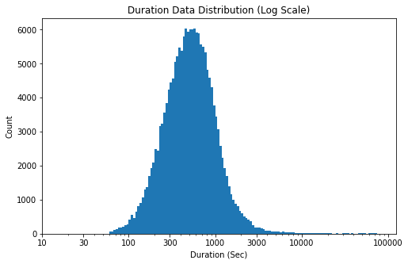

```python
binsize = 0.025
bins= 10 ** np.arange(1.6, np.log10(ford['duration_sec'].max()+ binsize), binsize)
plt.figure(figsize=(8,5))
plt.hist(data=ford, x='duration_sec', bins=bins)
plt.xscale('log')
plt.xticks([10, 30, 100, 300, 1000, 3000, 10000, 100000], [10, 30, 100, 300, 1000, 3000, 10000, 100000])
plt.xlabel('Duration (Sec)')
plt.ylabel('Count')
plt.title('Duration Data Distribution (Log Scale)');
```

## Distribution of Riders' Ages

Riders' ages range from less 20 to more than 60 years old and the majority of ages across the dataset between 30 and 40 years old. Plotted on a logarithmic scale, the distribution takes nearly normal distribution with long detail which defines the outliers clearly.

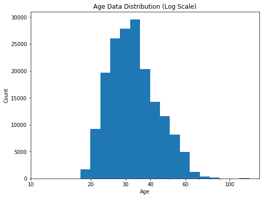

```python
binsize = 0.05
bins= 10 ** np.arange(1.1, np.log10(ford['age'].max()+ binsize), binsize)
plt.figure(figsize=(8,6))
plt.hist(data=ford, x='age', bins=bins)
plt.xscale('log')
plt.xticks([10, 20, 30, 40, 60, 100], [10, 20, 30, 40, 60, 100])
plt.xlabel('Age')
plt.ylabel('Count')
plt.title('Age Data Distribution (Log Scale)');
```

## Distribution of Trips' Distances

Taking advantage of the coordinates columns to come up with trips' distances where the majority are less than 10 km and the peak of distances travelled are in the range of 1 to 3 km. Plotting the data on a logarithmic scale clarified a range of data of zero values and an outlier of 69 km.

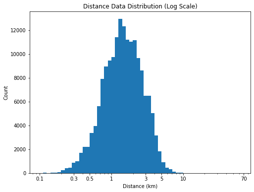

```python
binsize = 0.05
bins= 10 ** np.arange(-1, np.log10(ford['distance'].max()+ binsize), binsize)
plt.figure(figsize=(8,6))
plt.hist(data=ford, x='distance', bins=bins)
plt.xscale('log')
plt.xticks([0.1, 0.3, 0.5, 1, 3, 5, 10, 70], [ 0.1, 0.3, 0.5, 1, 3, 5, 10, 70])
plt.xlabel('Distance (km)')
plt.ylabel('Count')
plt.title('Distance Data Distribution (Log Scale)');
```

## Distance Vs. Duration and Age

Running a small sample of data to have an overview of data trends and it turns out that distance has a positive correlation with duration. While it's not obvious with age. So, we use the logarithmic scale and it also confirmed the relation between both of distance and duration unlike the age. However, I still expect a positive correlation among them mainly due to the commonsense of the physical abilities with age or longer distances

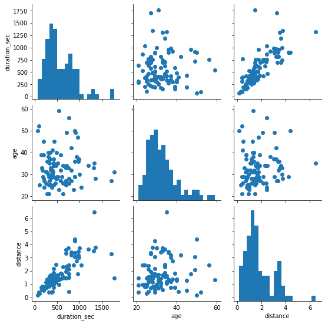

```python
# plot matrix: sample 500 diamondstrips so that plots are clearer
samples = np.random.choice(ford.shape[0], 100, replace = False)
ford_samp = ford.iloc[samples]
g = sb.PairGrid(data = ford_samp, vars = numeric_columns)
g = g.map_diag(plt.hist, bins = 20)
g.map_offdiag(plt.scatter);
```

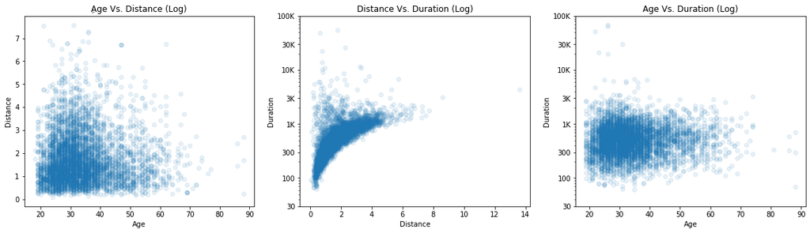

```python
plt.figure(figsize=[20,5])

plt.subplot(1,3,1)
samples = np.random.choice(ford.shape[0], 5000, replace = False)
ford_samp = ford.iloc[samples]
plt.scatter(data=ford_samp, x='age', y='distance', alpha = 1/10)
plt.xlabel('Age')
plt.ylabel('Distance')
plt.title('ِAge Vs. Distance (Log)')

plt.subplot(1,3,2)
samples = np.random.choice(ford.shape[0], 5000, replace = False)
ford_samp = ford.iloc[samples]
plt.scatter(data=ford_samp, x='distance', y='duration_sec', alpha = 1/10)
plt.xlabel('Distance')
plt.yscale('log')
plt.ylabel('Duration')
plt.yticks([30, 100, 300, 1000, 3000, 10000, 30000, 100000], [30, 100, 300, '1K', '3K', '10K', '30K', '100K'])
plt.title('Distance Vs. Duration (Log)')

plt.subplot(1,3,3)
samples = np.random.choice(ford.shape[0], 5000, replace = False)
ford_samp = ford.iloc[samples]
plt.scatter(data=ford_samp, x='age', y='duration_sec', alpha = 1/10)
plt.yscale('log')
plt.xlabel('Age')
plt.ylabel('Duration')
plt.yticks([30, 100, 300, 1000, 3000, 10000, 30000, 100000], [30, 100, 300, '1K', '3K', '10K', '30K', '100K'])
plt.title('Age Vs. Duration (Log)');
```

## Distance and duration in terms of time scale

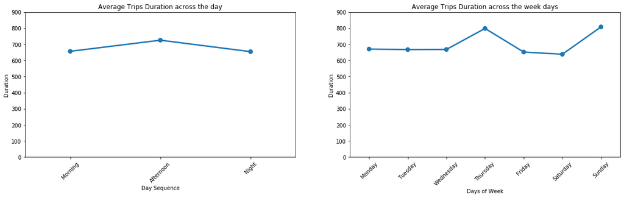

```python
plt.figure(figsize=[20,5])

plt.subplot(1,2,1)
sb.pointplot(data=ford, x='daysequence', y='duration_sec', errwidth=0)
plt.ylim(0, 900)
plt.xticks(rotation= 45)
plt.xlabel('Day Sequence')
plt.ylabel('Duration')
plt.title('Average Trips Duration across the day')

plt.subplot(1,2,2)
sb.pointplot(data=ford, x='dayofweek', y='duration_sec', errwidth=0)
plt.ylim(0, 900)
plt.xticks(rotation= 45)
plt.xlabel('Days of Week')
plt.ylabel('Duration')
plt.title('Average Trips Duration across the week days');
```

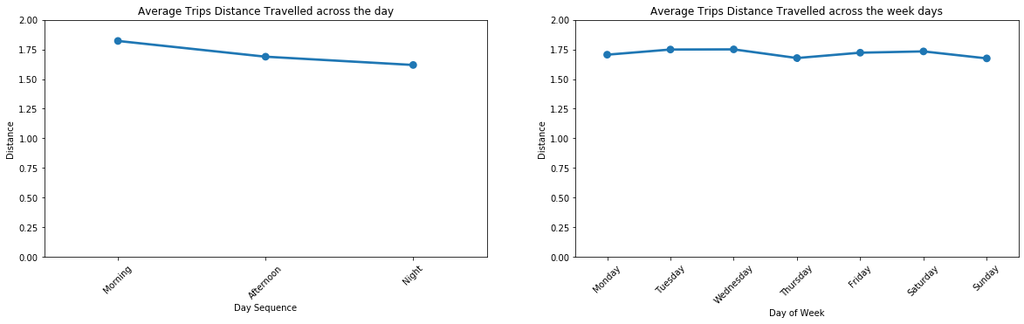

```python
plt.figure(figsize=[20,5])

plt.subplot(1,2,1)
sb.pointplot(data=ford, x='daysequence', y='distance')
plt.ylim(0,2)
plt.xticks(rotation= 45)
plt.xlabel('Day Sequence')
plt.ylabel('Distance')
plt.title('Average Trips Distance Travelled across the day')

plt.subplot(1,2,2)
sb.pointplot(data=ford, x='dayofweek', y='distance')
plt.ylim(0,2)
plt.xticks(rotation= 45)
plt.xlabel('Day of Week')
plt.ylabel('Distance')
plt.title('Average Trips Distance Travelled across the week days');
```

## Number of trips in terms of time scale

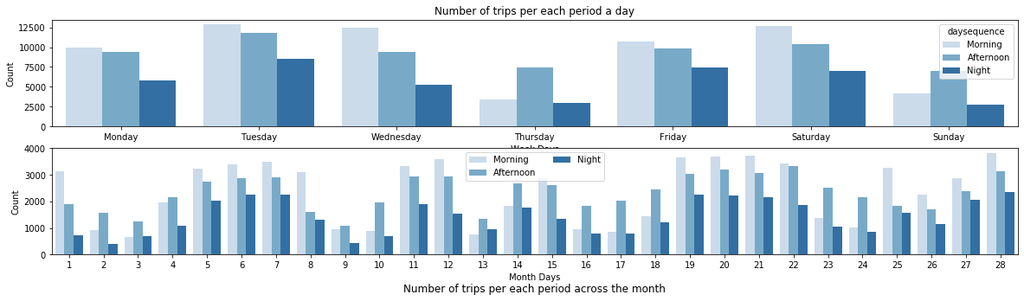

```python
plt.figure(figsize=[20,5])

plt.subplot(2,1,1)
sb.countplot(data= ford, x='dayofweek', hue='daysequence', palette="Blues")
plt.xlabel('Week Days')
plt.ylabel('Count')
plt.title('Number of trips per each period a day')

plt.subplot(2,1,2)
sb.countplot(data= ford, x='dayofmonth', hue='daysequence', palette="Blues")
plt.xlabel('Month Days')
plt.ylabel('Count')
plt.title('Number of trips per each period across the month', y=-0.4)
plt.legend(ncol = 2);
```

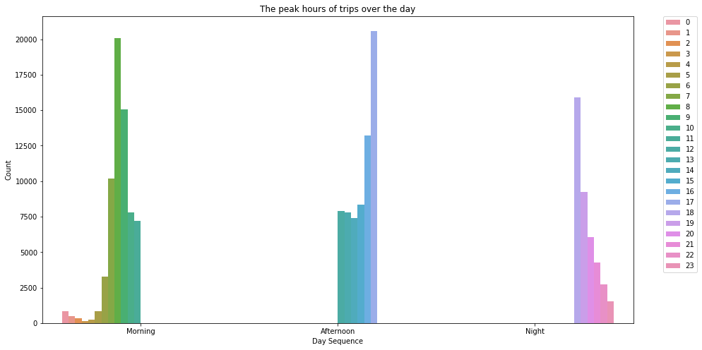

```python
plt.figure(figsize=[15,8])
sb.countplot(data=ford, x='daysequence', hue='starting_hour')
plt.legend(bbox_to_anchor=(1.05, 1), loc='upper left', borderaxespad=0.)
plt.xlabel('Day Sequence')
plt.ylabel('Count')
plt.title('The peak hours of trips over the day');
```

## Distance and duration in terms of miscellaneous variables

Using the multivariate plots for the sake of ensuring the triple relation of distance, duration and age. It demonstrated the positive relationship between trips' distances and durations in terms of the day periods across each weekday. In addition, Such notion got more solidified across the top five participating ages where their trips' distances and durations are in harmony. Finally, the afternoon period has the highest trips' duration on average over the weekdays while the morning period witnessed the longer travelled distances on average.

```
C:\Users\Ahmed Nasser\anaconda3\lib\site-packages\seaborn\axisgrid.py:243: UserWarning: The `size` parameter has been renamed to `height`; please update your code.
  warnings.warn(msg, UserWarning)
```

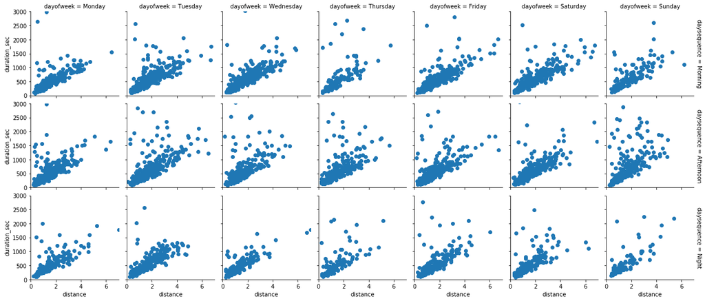

```python
#plotting the distance vs duration relation over day period of each week day
samples = np.random.choice(ford.shape[0], 5000, replace = False)
ford_samp = ford.iloc[samples]

g = sb.FacetGrid(data = ford_samp, col = 'dayofweek', row = 'daysequence', size = 2.5, margin_titles = True)
g.map(plt.scatter, 'distance', 'duration_sec')
plt.xlim(0, 7)
plt.ylim(0, 3000);
```

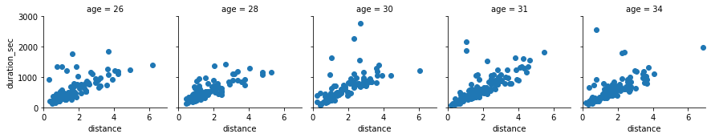

```python
#plotting the distance vs duration relation over the top 5 participating ages
samples = np.random.choice(ford.shape[0], 2000, replace = False)
ford_samp = ford.iloc[samples]

top_ten_ages = ford_samp['age'].value_counts().index[:5]
ford_ages = ford_samp.loc[ford['age'].isin(top_ten_ages )]

g = sb.FacetGrid(data = ford_ages, col = 'age', size = 2.5, margin_titles = True)
g.map(plt.scatter, 'distance', 'duration_sec')
plt.xlim(0, 7)
plt.ylim(0, 3000);
```

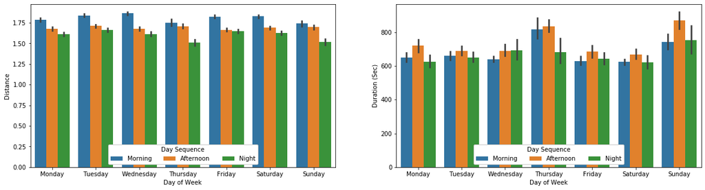

```python
#plotting the week periods across the week days in terms of distance and duration
plt.figure(figsize=[20,5])

plt.subplot(1,2,1)
sb.barplot(data = ford, x = 'dayofweek', y = 'distance', hue = 'daysequence')
plt.legend(loc = 8, ncol = 3, framealpha = 1, title = 'Day Sequence')
plt.xlabel('Day of Week')
plt.ylabel('Distance')


plt.subplot(1,2,2)
sb.barplot(data = ford, x = 'dayofweek', y = 'duration_sec', hue = 'daysequence')
plt.legend(loc = 8, ncol = 3, framealpha = 1, title = 'Day Sequence')
plt.xlabel('Day of Week')
plt.ylabel('Duration (Sec)');
```